# Dimensionality reduction techniques

Note: First of all, if you (like me) are rather unfamiliar with the topic, take my interpretations with a grain of salt..

## Loading the data

Loading the data from a local folder

```r
library(readr)
human <- read.csv("data/human.csv", row.names = 1)
colnames(human)
```

```
## [1] "Country"   "Edu2.FM"   "Labo.FM"   "Life.Exp"  "Edu.Exp"   "GNI"
## [7] "Mat.Mor"   "Ado.Birth" "Parli.F"
```

Moving the country names to row names

```r
# move the country names to rownames
library(tibble)
human <- column_to_rownames(human, "Country")
```

## Graphical overview of the data

Visualizing the data with ggpairs

(Apparently you can change the figure sizes at the beginning of the chunk!)

```r
# Access GGally

library(GGally)
```

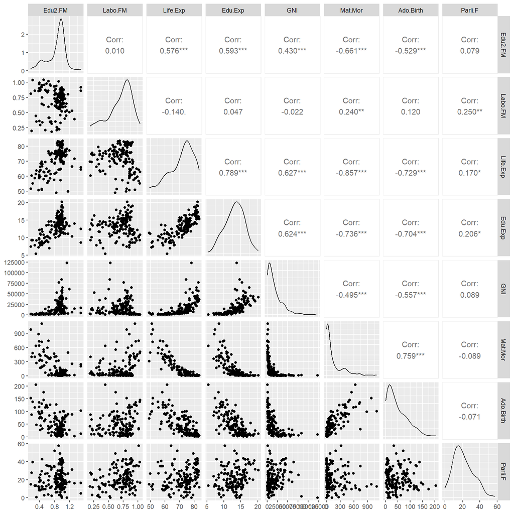

```r
ggpairs(human, progress = FALSE)
```

Observations based on the plots:

- High female to male ratio in secondary education (‘Edu2.FM’):
  - positively correlated with life expectancy (‘Life.Exp.’) and expected years of education (‘Edu.Exp’) (good things)
    - Edu.Exp and Edu2.FM are likely correlated as they are not really independent from each other
  - negatively correlated with maternal mortality (‘Mat.Mor’) and adolecent births (‘Ado.Birth’) (bad things)
  - it is maybe a bit surprisingly only very slightly or not correlated with parlamentary representation of women (‘Parli.F’)
- High female to male ratio (‘Labo.FM’) is not correlated with ‘Edu2.FM’ but seems to be positively correlated with ‘Mat.Mort’ and ‘Parl.F’.

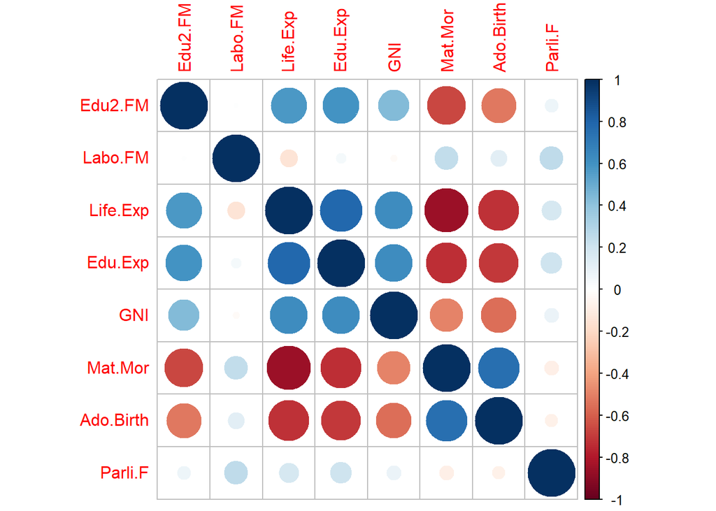

```r
# Access corrplot
library(corrplot)
# compute the correlation matrix and visualize it with corrplot
library(dplyr)
cor(human) %>% corrplot()
```

## Principal component analysis without scaling the variables

Perform principal component analysis (PCA) on the raw (non-standardized) human data.

Show the variability captured by the principal components.

Draw a biplot displaying the observations by the first two principal components (PC1 coordinate in x-axis, PC2 coordinate in y-axis), along with arrows representing the original variables. (0-2 points)

```r
# perform principal component analysis (with the SVD method) without scaling
not_scaled_human <- prcomp(human)

summary(not_scaled_human)
```

```
## Importance of components:
##                              PC1      PC2   PC3   PC4   PC5   PC6    PC7    PC8
## Standard deviation     1.854e+04 185.5219 25.19 11.45 3.766 1.566 0.1912 0.1591
## Proportion of Variance 9.999e-01   0.0001  0.00  0.00 0.000 0.000 0.0000 0.0000
## Cumulative Proportion  9.999e-01   1.0000  1.00  1.00 1.000 1.000 1.0000 1.0000
```

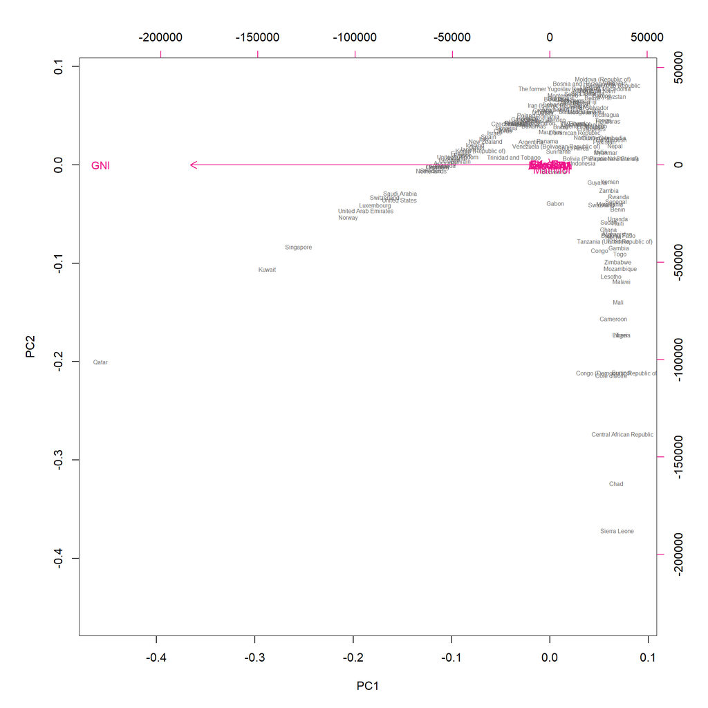

```r
# draw a biplot of the principal component representation and the original variables
biplot(not_scaled_human, choices = 1:2, cex = c(0.5, 0.9), col = c("grey40", "deeppink2"))
```

This doesn’t seem to work as the only arrow we see represents ‘GNI’. All of the other arrows and variable names are clustered in the in one small mess.

Summaries of the unscaled data:

```r
# summary of the human data
summary(human)
```

```
##     Edu2.FM          Labo.FM          Life.Exp        Edu.Exp
##  Min.   :0.1717   Min.   :0.1857   Min.   :49.00   Min.   : 5.40
##  1st Qu.:0.7264   1st Qu.:0.5984   1st Qu.:66.30   1st Qu.:11.25
##  Median :0.9375   Median :0.7535   Median :74.20   Median :13.50
##  Mean   :0.8529   Mean   :0.7074   Mean   :71.65   Mean   :13.18
##  3rd Qu.:0.9968   3rd Qu.:0.8535   3rd Qu.:77.25   3rd Qu.:15.20
##  Max.   :1.4967   Max.   :1.0380   Max.   :83.50   Max.   :20.20
##       GNI            Mat.Mor         Ado.Birth         Parli.F
##  Min.   :   581   Min.   :   1.0   Min.   :  0.60   Min.   : 0.00
##  1st Qu.:  4198   1st Qu.:  11.5   1st Qu.: 12.65   1st Qu.:12.40
##  Median : 12040   Median :  49.0   Median : 33.60   Median :19.30
##  Mean   : 17628   Mean   : 149.1   Mean   : 47.16   Mean   :20.91
##  3rd Qu.: 24512   3rd Qu.: 190.0   3rd Qu.: 71.95   3rd Qu.:27.95
##  Max.   :123124   Max.   :1100.0   Max.   :204.80   Max.   :57.50
```

Here, ‘GNI’ has numerically a lot higher values than the other variables. Maybe that is why it is the only arrow present in the plot.

## Principal component analysis for scaled variables

Scaling the variables:

```r
# standardize the variables
human_std <- scale(human)

# print out summaries of the standardized variables
summary(human_std)
```

```
##     Edu2.FM           Labo.FM           Life.Exp          Edu.Exp
##  Min.   :-2.8189   Min.   :-2.6247   Min.   :-2.7188   Min.   :-2.7378
##  1st Qu.:-0.5233   1st Qu.:-0.5484   1st Qu.:-0.6425   1st Qu.:-0.6782
##  Median : 0.3503   Median : 0.2316   Median : 0.3056   Median : 0.1140
##  Mean   : 0.0000   Mean   : 0.0000   Mean   : 0.0000   Mean   : 0.0000
##  3rd Qu.: 0.5958   3rd Qu.: 0.7350   3rd Qu.: 0.6717   3rd Qu.: 0.7126
##  Max.   : 2.6646   Max.   : 1.6632   Max.   : 1.4218   Max.   : 2.4730
##       GNI             Mat.Mor          Ado.Birth          Parli.F
##  Min.   :-0.9193   Min.   :-0.6992   Min.   :-1.1325   Min.   :-1.8203
##  1st Qu.:-0.7243   1st Qu.:-0.6496   1st Qu.:-0.8394   1st Qu.:-0.7409
##  Median :-0.3013   Median :-0.4726   Median :-0.3298   Median :-0.1403
##  Mean   : 0.0000   Mean   : 0.0000   Mean   : 0.0000   Mean   : 0.0000
##  3rd Qu.: 0.3712   3rd Qu.: 0.1932   3rd Qu.: 0.6030   3rd Qu.: 0.6127
##  Max.   : 5.6890   Max.   : 4.4899   Max.   : 3.8344   Max.   : 3.1850
```

After scaling the variation seems to be more similar than before scaling.

Principal component analysis for scaled variables:

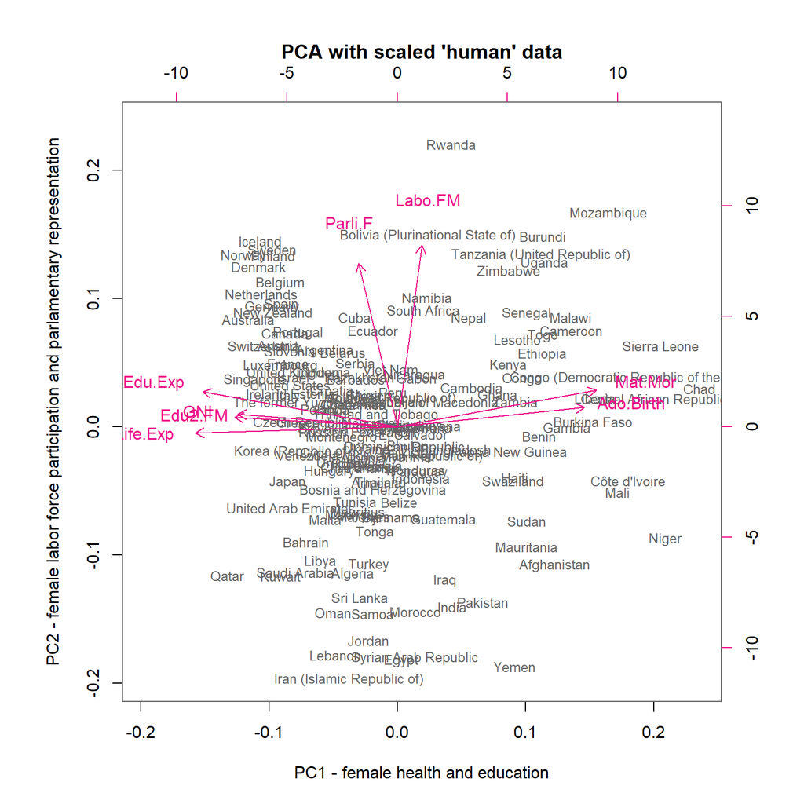

```r
# perform principal component analysis (with the SVD method)
pca_human <- prcomp(human_std)

# draw a biplot of the principal component representation and the original variables
biplot(pca_human, choices = 1:2, cex = c(0.8, 1), col = c("grey40", "deeppink2"), main = "PCA with scaled 'human' data", xlab = "PC1 - female health and education", ylab = "PC2 - female labor force participation and parlamentary representation")
```

PCA reduces the variables into principle components represented by the axes

- The variables in the plot are represented by the arrows.
- If I understood this correctly, in this case PC2 is affected by ‘Labo.FM’ and ‘Parli.F’, and the rest of the variables mainly affect PC1
  - If the variables are positively correlated, the angle between them is small
  - 90 degree angle - no correlation
  - 180 degree angle - negative correlation
- The results here are similar as observed based on the ‘ggpairs’ plot earlier:
  - ‘Edu.Exp’, ‘Life.Exp’, ‘GNI’ and ‘Edu2.FM’ are positively correlated with each other
  - ‘Parli.F’ and ‘Labo.FM’ are positively correlated with each other, but not really with other variables
  - ‘Mat.Mort’ and ‘Ado.Birth’ are positively with each other, and negatively correlated with ‘Edu.Exp’, ‘Life.Exp’, ‘GNI’ and ‘Edu2.FM’
- The observations that are more similar regarding these variables are clustered together
  - for example, Nordic countries appear very close to each other at the upper left corner

## PCA for the Tea time data

Loading the data and converting them to factors

```r
# loading the libraries
library(dplyr)
library(tidyr)
library(ggplot2)
library(tidyverse)
#loading the data and converting strings to factors
tea <- read.csv("https://raw.githubusercontent.com/KimmoVehkalahti/Helsinki-Open-Data-Science/master/datasets/tea.csv", stringsAsFactors = TRUE)
```

Exploring the data

```r
colnames(tea)
```

```
##  [1] "breakfast"        "tea.time"         "evening"          "lunch"
##  [5] "dinner"           "always"           "home"             "work"
##  [9] "tearoom"          "friends"          "resto"            "pub"
## [13] "Tea"              "How"              "sugar"            "how"
## [17] "where"            "price"            "age"              "sex"
## [21] "SPC"              "Sport"            "age_Q"            "frequency"
## [25] "escape.exoticism" "spirituality"     "healthy"          "diuretic"
## [29] "friendliness"     "iron.absorption"  "feminine"         "sophisticated"
## [33] "slimming"         "exciting"         "relaxing"         "effect.on.health"
```

```r
view(tea)

library(dplyr)
library(tidyr)
# column names to keep in the dataset, I added a few to the Exercise code...
keep_columns <- c("Tea", "How", "how", "sugar", "where", "lunch", "evening", "pub")

# select the 'keep_columns' to create a new dataset
tea_time <- select(tea, keep_columns)
# look at the summaries and structure of the data
str(tea_time)
```

```
## 'data.frame':    300 obs. of  8 variables:
##  $ Tea    : Factor w/ 3 levels "black","Earl Grey",..: 1 1 2 2 2 2 2 1 2 1 ...
##  $ How    : Factor w/ 4 levels "alone","lemon",..: 1 3 1 1 1 1 1 3 3 1 ...
##  $ how    : Factor w/ 3 levels "tea bag","tea bag+unpackaged",..: 1 1 1 1 1 1 1 1 2 2 ...
##  $ sugar  : Factor w/ 2 levels "No.sugar","sugar": 2 1 1 2 1 1 1 1 1 1 ...
##  $ where  : Factor w/ 3 levels "chain store",..: 1 1 1 1 1 1 1 1 2 2 ...
##  $ lunch  : Factor w/ 2 levels "lunch","Not.lunch": 2 2 2 2 2 2 2 2 2 2 ...
##  $ evening: Factor w/ 2 levels "evening","Not.evening": 2 2 1 2 1 2 2 1 2 1 ...
##  $ pub    : Factor w/ 2 levels "Not.pub","pub": 1 1 1 1 1 1 1 1 1 1 ...
```

```r
summary(tea_time)
```

```
##         Tea         How                      how           sugar
##  black    : 74   alone:195   tea bag           :170   No.sugar:155
##  Earl Grey:193   lemon: 33   tea bag+unpackaged: 94   sugar   :145
##  green    : 33   milk : 63   unpackaged        : 36
##                  other:  9
##                   where           lunch            evening         pub
##  chain store         :192   lunch    : 44   evening    :103   Not.pub:237
##  chain store+tea shop: 78   Not.lunch:256   Not.evening:197   pub    : 63
##  tea shop            : 30
##
```

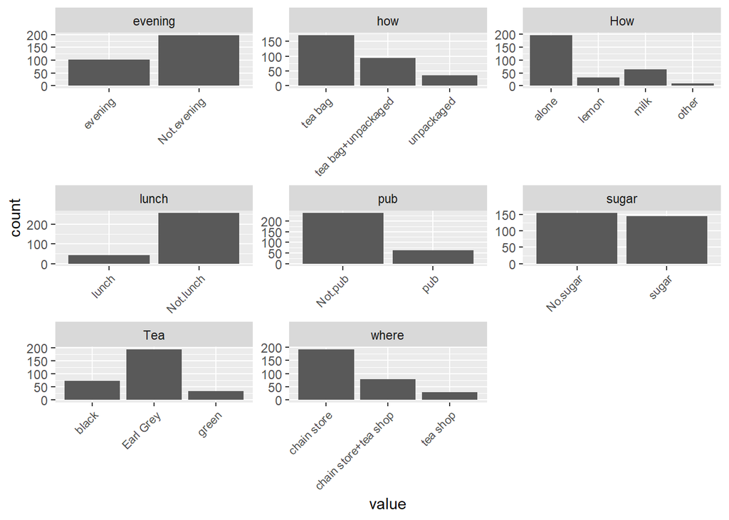

```r
# visualize the dataset
library(ggplot2)
pivot_longer(tea_time, cols = everything()) %>%
  ggplot(aes(value)) + facet_wrap("name", scales = "free") +
  geom_bar() + theme(axis.text.x = element_text(angle = 45, hjust = 1, size = 8))
```

I also tried the visualization of the whole ‘tea’ data but that did not work with ‘geom_bar’, as ‘age’ was numeric. When that was removed, the visualization of the whole data did not really work as the plots were too small to see the bars.

```r
library(FactoMineR)
```

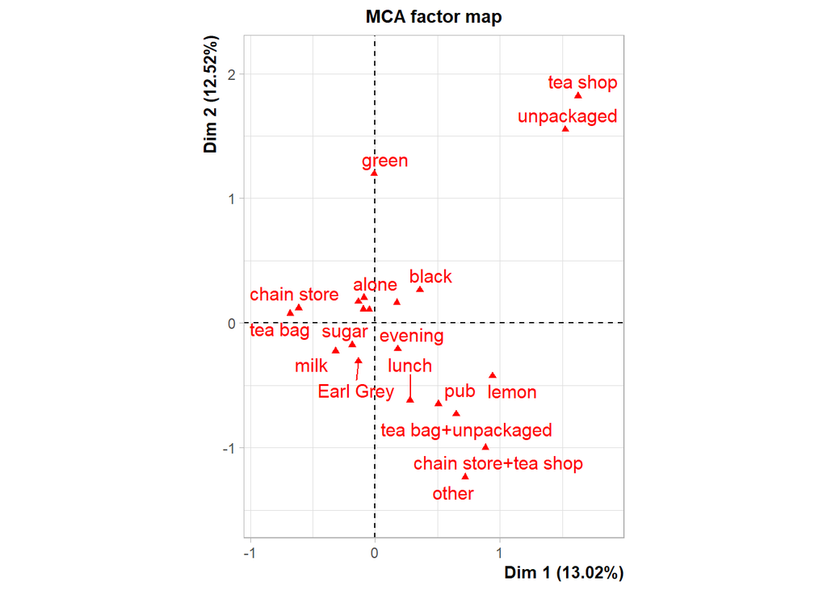

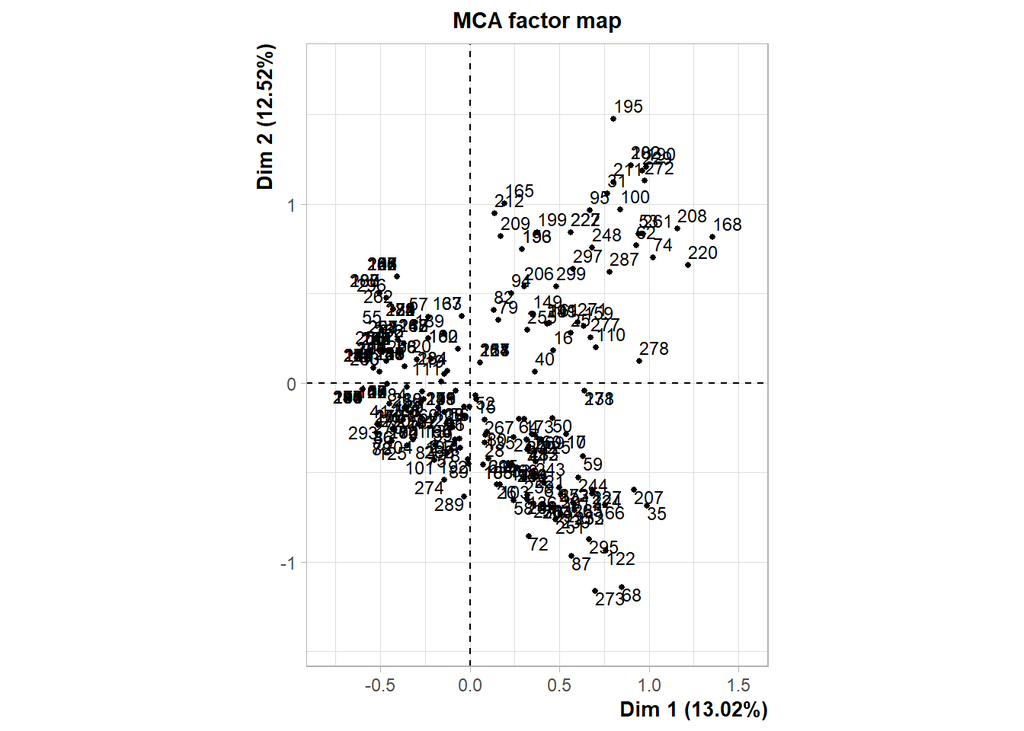

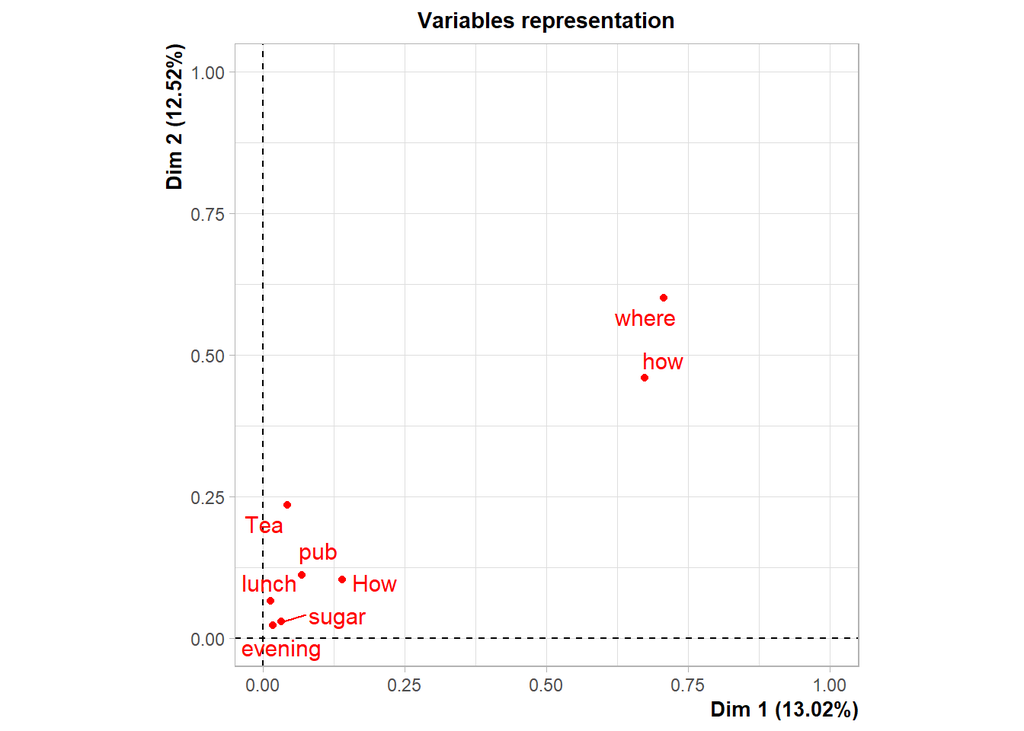

```r
# multiple correspondence analysis
library(FactoMineR)
mca <- MCA(tea_time, graph = T)
```

```r
# summary of the model
summary(mca)
```

```
##
## Call:
## MCA(X = tea_time, graph = T)
##
##
## Eigenvalues
##                        Dim.1   Dim.2   Dim.3   Dim.4   Dim.5   Dim.6   Dim.7
## Variance               0.212   0.203   0.173   0.147   0.139   0.136   0.115
## % of var.             13.020  12.523  10.654   9.065   8.553   8.371   7.053
## Cumulative % of var.  13.020  25.542  36.196  45.262  53.815  62.185  69.238
##                        Dim.8   Dim.9  Dim.10  Dim.11  Dim.12  Dim.13
## Variance               0.107   0.105   0.096   0.081   0.065   0.046
## % of var.              6.607   6.448   5.938   4.974   3.976   2.819
## Cumulative % of var.  75.846  82.294  88.232  93.205  97.181 100.000
##
## Individuals (the 10 first)
##                       Dim.1    ctr   cos2    Dim.2    ctr   cos2    Dim.3
## 1                  | -0.404  0.257  0.188 |  0.243  0.096  0.068 | -0.224
## 2                  | -0.369  0.215  0.109 |  0.219  0.078  0.038 | -0.644
## 3                  | -0.366  0.211  0.188 |  0.091  0.014  0.012 |  0.086
## 4                  | -0.538  0.456  0.521 |  0.084  0.012  0.013 |  0.182
## 5                  | -0.366  0.211  0.188 |  0.091  0.014  0.012 |  0.086
## 6                  | -0.441  0.306  0.360 |  0.179  0.053  0.059 | -0.156
## 7                  | -0.441  0.306  0.360 |  0.179  0.053  0.059 | -0.156
## 8                  | -0.295  0.137  0.061 |  0.131  0.028  0.012 | -0.402
## 9                  |  0.265  0.110  0.050 | -0.474  0.367  0.160 | -0.464
## 10                 |  0.536  0.452  0.193 | -0.285  0.133  0.054 | -0.546
##                       ctr   cos2
## 1                   0.097  0.058 |
## 2                   0.799  0.331 |
## 3                   0.014  0.010 |
## 4                   0.064  0.060 |
## 5                   0.014  0.010 |
## 6                   0.047  0.045 |
## 7                   0.047  0.045 |
## 8                   0.312  0.113 |
## 9                   0.414  0.153 |
## 10                  0.573  0.200 |
##
## Categories (the 10 first)
```

[output cut: 18 more lines]

```
## other               -3.762 |  -2.669  15.430   0.220  -8.116 |
## tea bag              1.500 |   0.054   0.118   0.004   1.063 |
## tea bag+unpackaged  -8.542 |  -0.296   1.978   0.040  -3.454 |
## unpackaged           9.905 |   0.518   2.327   0.037   3.309 |
##
## Categorical variables (eta2)
##                      Dim.1 Dim.2 Dim.3
## Tea                | 0.043 0.235 0.330 |
## How                | 0.139 0.103 0.323 |
## how                | 0.673 0.460 0.061 |
## sugar              | 0.032 0.029 0.316 |
## where              | 0.707 0.600 0.083 |
## lunch              | 0.013 0.066 0.079 |
## evening            | 0.017 0.023 0.146 |
## pub                | 0.068 0.112 0.047 |
```

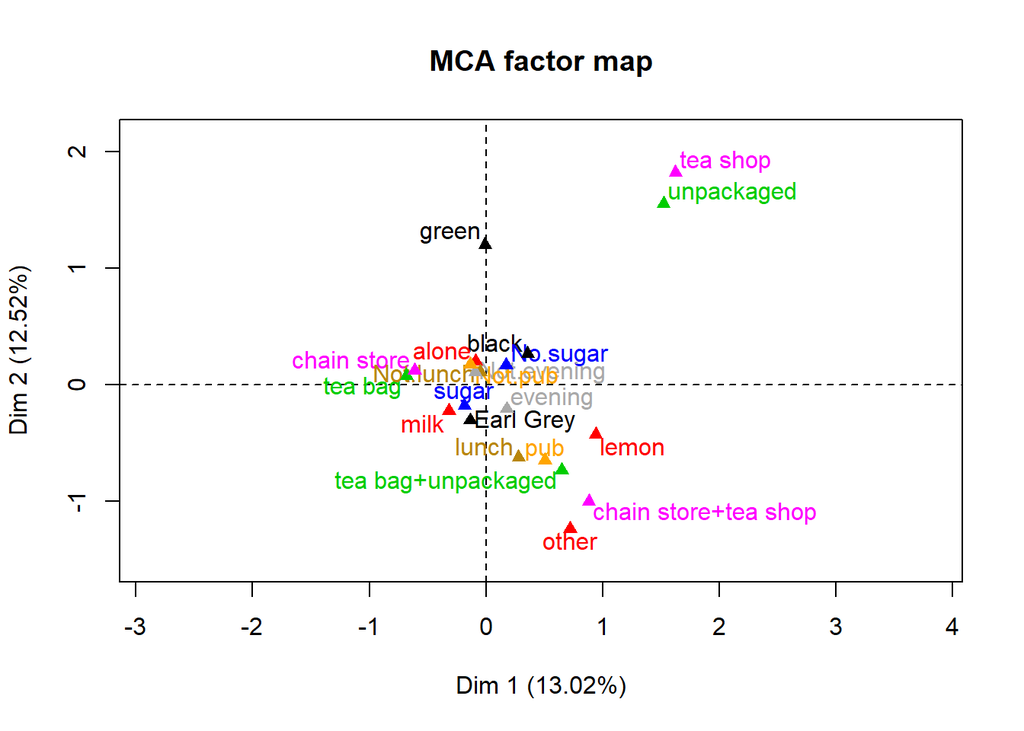

```r
# visualize MCA
plot(mca, invisible=c("ind"), graph.type = "classic", habillage = "quali")
```

- Based on the MCA factor plot, for example tea shop is associated with unpackaged tea, makes sense